# MrOS_HAllA_results

Kate Bowie

2024-12-28

# Set-up

```r
library(here)
library(phyloseq)
library(dplyr)
```

```r
library(tidyr)
library(ggplot2)
library(microshades)
library(patchwork)
library(cowplot)
library(ggpubr)
library(rstatix)
library(microbiome)
library(reshape2)
library(magrittr)
library(ggbeeswarm)
library(treemap)
```

# Data origin

This ps object was cleaned up in Box/Kate/MrOS/data/Analyses/MrOS_EDA.Rmd. ALl of the data is described explicitly in that RMD. The ps object is *rarefied*

**Things I want to answer:** 1. How many people are dialister/mobiluncus present in? 2. What is the relative abundance only for the people that have it. 3. And what directions the associations are in

```r
load(here("data", "Final_Analyses", "ps_subcat.RData"))

# Creating a variable with an untouched ps object
ps_orig <- ps
melt_ps <- psmelt(ps)
```

# Genus level

```r
ps_g <- ps %>% tax_glom(., "Genus")
ps_g <- subset_taxa(ps_g, taxa_sums(ps_g) > 0)


ps_g_rel <- transform_sample_counts(ps_g, function(x) 100* x/sum(x))
```

# Dialister

Dialister is associated with BMI_group (according to HAllA)

```r
ps_dia <- ps_g_rel %>%
  subset_taxa(., Genus == "Dialister")
```

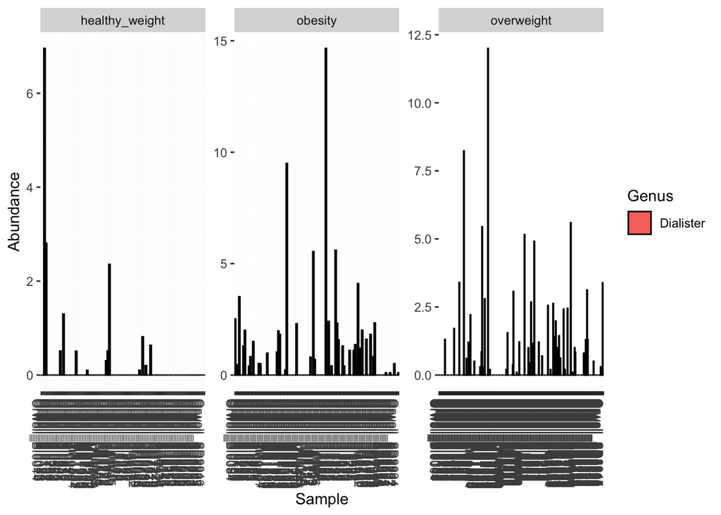

```r
plot_bar(ps_dia, x = "Sample", y = "Abundance", fill = "Genus") + facet_wrap(~BMI_group, scales = "free")
```

### How many people have Dialister?

```r
ps_dia <- subset_samples(ps_dia, sample_sums(ps_dia) > 0)

ps_d <- ps_g_rel %>%
  subset_samples(., (sample_names(ps_g_rel) %in% sample_names(ps_dia)))

ps_d <- subset_taxa(ps_d, taxa_sums(ps_d) >0)

meta_d <- data.frame(ps_d@sam_data)
```

There are 110 people that have dialister in their urinary microbiomes.

### Rel abundance

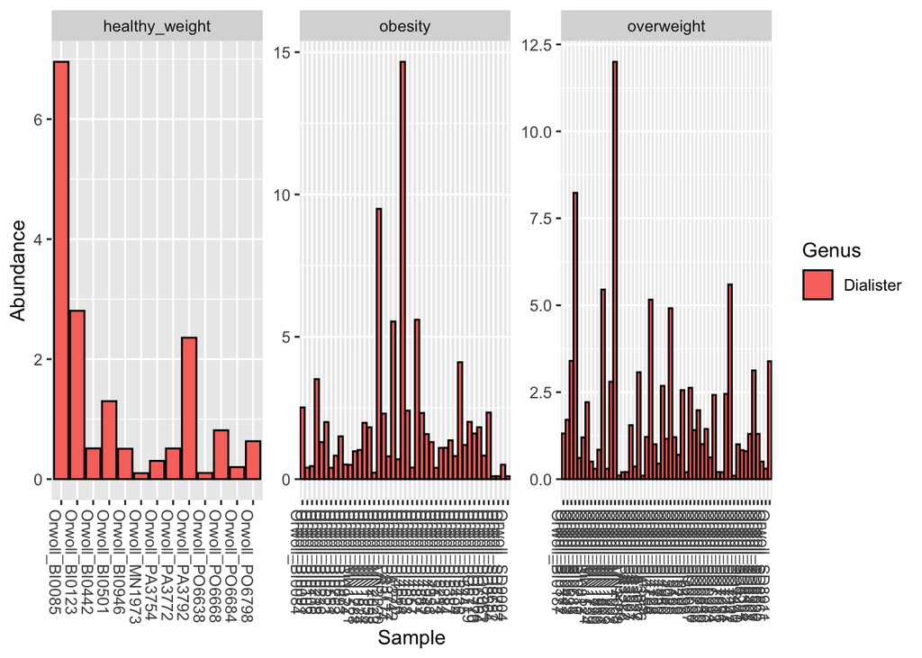

```r
ps_d %>%
  subset_taxa(., Genus == "Dialister") %>%
  plot_bar(., x = "Sample", y = "Abundance", fill = "Genus") + facet_wrap(~BMI_group, scales = "free")
```

Healthy weight: 13/104 –> 12.5% Overweight: 53/253 –> 20.9% Obesity: 44/118 –> 37.3%

### Rel abundance - boxplots

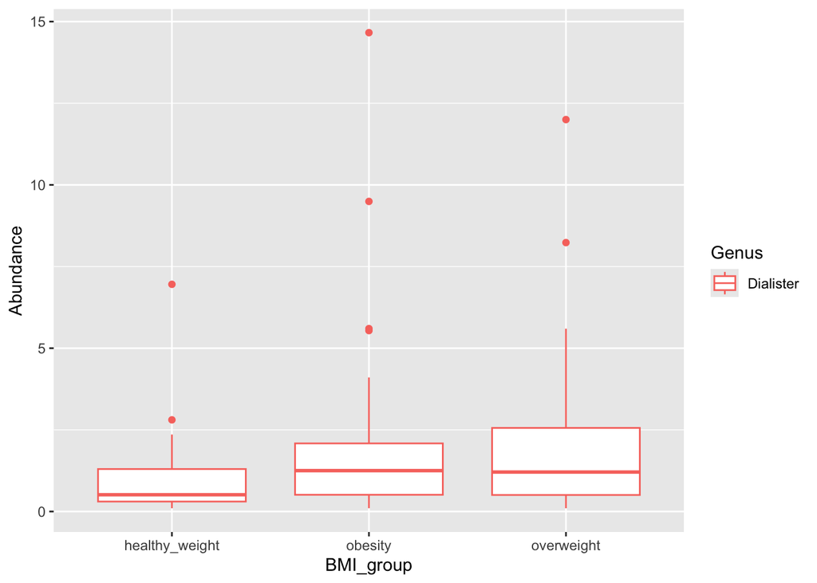

```r
ps_d %>%
  subset_taxa(., Genus == "Dialister") %>%
  psmelt() %>%
  ggplot(., aes(x = BMI_group, y = Abundance, color = Genus)) + geom_boxplot()
```

```r
d_smelt <-
  ps_d %>%
  subset_taxa(., Genus == "Dialister") %>%
  psmelt()
```

#### stats

```r
# Compute the analysis of variance
res.aov <- aov(Abundance ~ BMI_group, data = d_smelt)
# Summary of the analysis
summary(res.aov)
```

```
##              Df Sum Sq Mean Sq F value Pr(>F)
## BMI_group     2    4.4   2.211     0.4  0.672
## Residuals   107  592.1   5.533
```

```r
# Test for normality
shapiro.test(d_smelt$Abundance) # Non-normal! ... so anova is not appropriate
```

```
##
##  Shapiro-Wilk normality test
##
## data:  d_smelt$Abundance
## W = 0.66975, p-value = 2.187e-14
```

```r
kruskal.test(Abundance ~ BMI_group, data = d_smelt)
```

```
##
##  Kruskal-Wallis rank sum test
##
## data:  Abundance by BMI_group
## Kruskal-Wallis chi-squared = 2.2861, df = 2, p-value = 0.3188
```

#### proportion test

Ref: http://www.sthda.com/english/wiki/two-proportions-z-test-in-r#what-is-two-proportions-z-test

```r
# x: # of people with Dialister
# n: total # of people in that group

prop.test(x = c(13, 53, 44), n = c(104, 253, 118), p = NULL, alternative = "two.sided",
          correct = TRUE)
```

```
##
##  3-sample test for equality of proportions without continuity correction
##
## data:  c(13, 53, 44) out of c(104, 253, 118)
## X-squared = 20.572, df = 2, p-value = 3.41e-05
## alternative hypothesis: two.sided
## sample estimates:
##    prop 1    prop 2    prop 3
## 0.1250000 0.2094862 0.3728814
```

#### visualization tests

##### lollipop

```r
#Healthy weight: 13/104 --> 12.5%
#Overweight: 53/253 --> 20.9%
#Obesity: 44/118 --> 37.3%

melt_ps$BMI_group <- factor(melt_ps$BMI_group, levels = c("healthy_weight", "overweight", "obesity"))

melt_ps$BMI_title <- "overweight"
melt_ps$BMI_title[melt_ps$BMI_group == "healthy_weight"] <- "healthy \nweight"
melt_ps$BMI_title[melt_ps$BMI_group == "obesity"] <- "obese"
melt_ps$BMI_title <- factor(melt_ps$BMI_title, levels = c("obese", "overweight", "healthy \nweight"))

y_title <- expression(paste("Proportion of samples containing ", italic("Dialister")))

# plot
BMI_lolli <- melt_ps %>%
  filter(Genus == "Dialister") %>%
  group_by(BMI_title) %>%
  count(Abundance > 0) %>%
  mutate(percent_n = (n/sum(n))*100) %>%
  filter(n < 70) %>%
  ggplot(., aes(x=BMI_title, y= percent_n )) +
    geom_segment( aes(x=BMI_title ,xend=BMI_title, y=0, yend=percent_n), color="black") +
    geom_point(size=3, color="#69b3a2") +
  theme_bw() +
  coord_flip() +
  ylab(y_title) + xlab("")
```

##### tree map

[figure not shown]

```r
# Plot
melt_ps %>%
  filter(Genus == "Dialister") %>%
  group_by(BMI_group) %>%
  count(Abundance > 0) %>%
  treemap(.,

            # data
            index="BMI_group",
            vSize="n",
            type="index",

            # Main
            title="",
            palette="Dark2",

            # Borders:
            border.col=c("black"),
            border.lwds=1,

            # Labels
            fontsize.labels=0.5,
            fontcolor.labels="white",
            fontface.labels=1,
            align.labels=c("left", "top"),
            overlap.labels=0.5,
            inflate.labels=T
            )
```

##### donut

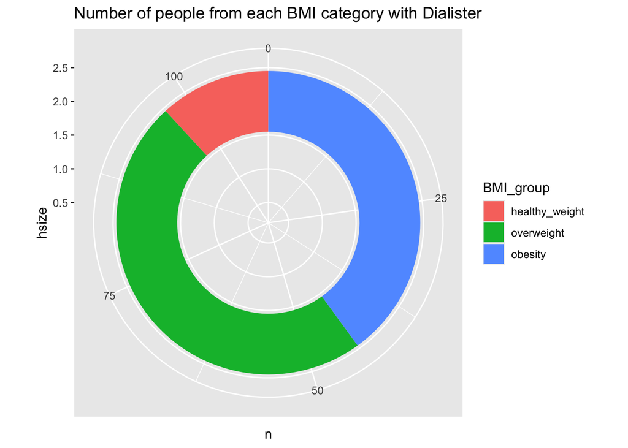

```r
d_smelt$BMI_group <- factor(d_smelt$BMI_group, levels = c("healthy_weight", "overweight", "obesity"))

hsize <- 2

d_smelt %>%
  mutate(x = hsize) %>%
  group_by(BMI_group) %>%
  count(Abundance >0) %>%
  ggplot(., aes(x = hsize, y = n, fill = BMI_group)) +
  geom_col() +
  coord_polar(theta = "y") +
  xlim(c(0.2, hsize + 0.5)) +
  ggtitle("Number of people from each BMI category with Dialister")
```

# irritation and dialister

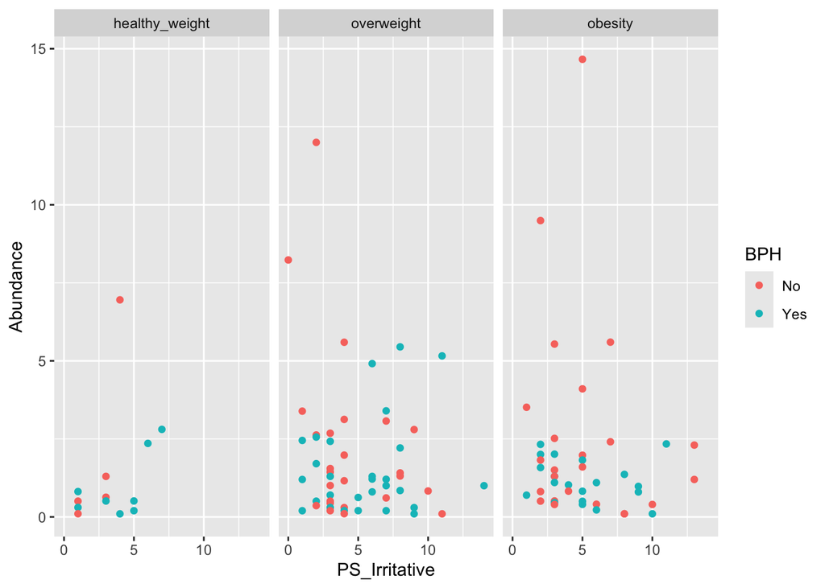

```r
ggplot(d_smelt, aes(x = PS_Irritative, y = Abundance, color = BPH)) + geom_point() + facet_wrap(~BMI_group)
```

```r
# Testing normality
shapiro.test(d_smelt$Abundance)
```

```
##
##  Shapiro-Wilk normality test
##
## data:  d_smelt$Abundance
## W = 0.66975, p-value = 2.187e-14
```

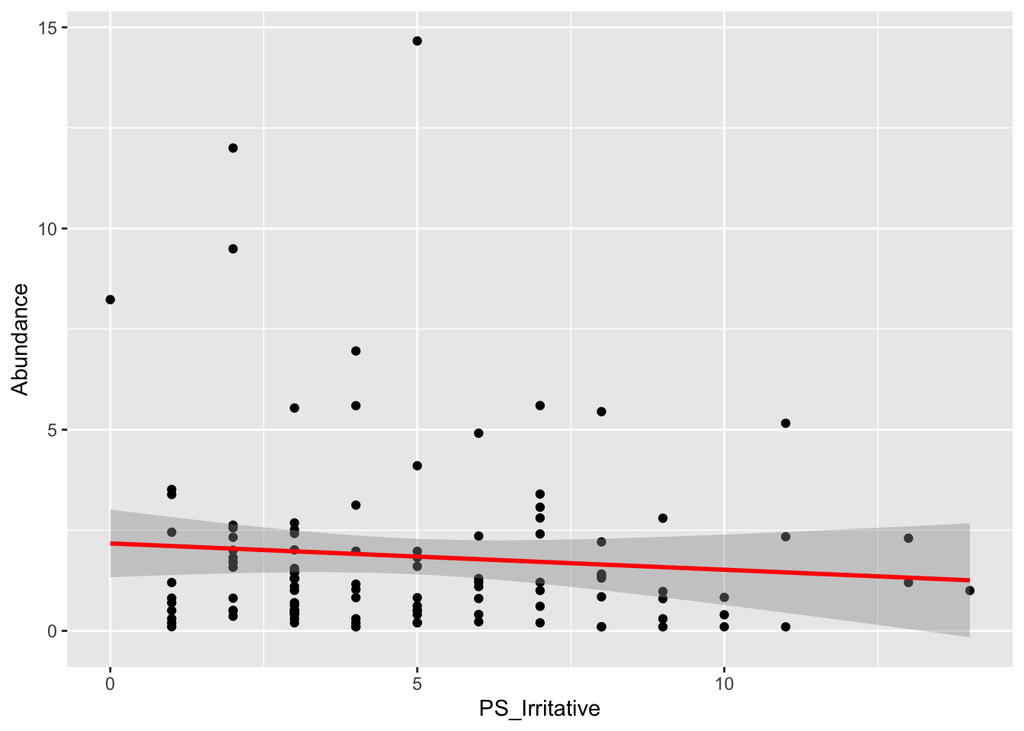

```r
# testing Observed
ggplot(d_smelt, aes(x = PS_Irritative, y = Abundance)) + geom_point() + stat_smooth(method = "lm", col = "red")
```

```r
res <- cor.test(d_smelt$PS_Irritative, d_smelt$Abundance,
                    method = "spearman") #pearson is for normal, spearman is for non-normal
res$p.value
```

```
## [1] 0.460482
```

# dialister and obstructive

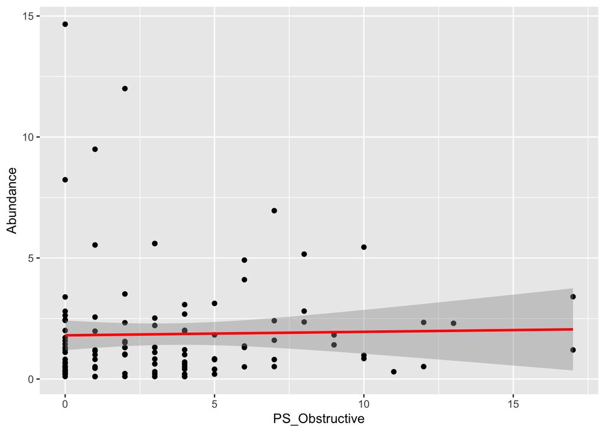

```r
# testing Observed
ggplot(d_smelt, aes(x = PS_Obstructive, y = Abundance)) + geom_point() + stat_smooth(method = "lm", col = "red")
```

```r
res <- cor.test(d_smelt$PS_Obstructive, d_smelt$Abundance,
                    method = "spearman") #pearson is for normal, spearman is for non-normal
res$p.value
```

```
## [1] 0.143014
```

No associations between abundance of dialister and obstructive nor irritative symptoms

```r
meta_ps$dialister <- "No"
meta_ps$dialister[meta_ps$Sample %in% meta_d$Sample] <- "Yes"


pairwise.wilcox.test(meta_ps$PS_Irritative, meta_ps$dialister)
```

```
##
##  Pairwise comparisons using Wilcoxon rank sum test with continuity correction
##
## data:  meta_ps$PS_Irritative and meta_ps$dialister
##
##     No
## Yes 0.18
##
## P value adjustment method: holm
```

```r
pairwise.wilcox.test(meta_ps$PS_Obstructive, meta_ps$dialister)
```

```
##
##  Pairwise comparisons using Wilcoxon rank sum test with continuity correction
##
## data:  meta_ps$PS_Obstructive and meta_ps$dialister
##
##     No
## Yes 0.63
##
## P value adjustment method: holm
```

### Dialister with BPH

```r
table(meta_ps$dialister, meta_ps$BPH)
```

```
##
##        No Yes
##   No  193 172
##   Yes  54  56
```

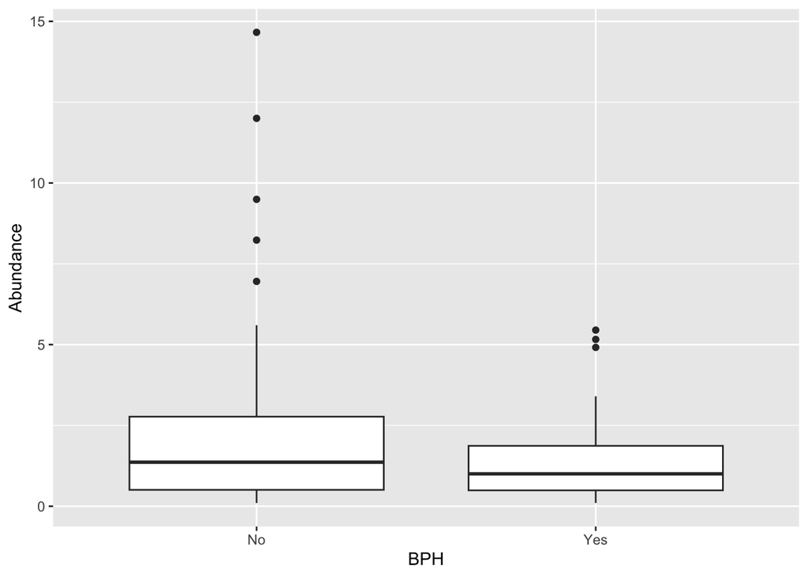

```r
ggplot(d_smelt, aes(y = Abundance, x = BPH)) + geom_boxplot()
```

### beta diversity

I want to see if dialister is important for BMI and beta diversity

```r
ps_nondia <- ps_g %>%
  subset_taxa(., Genus != "Dialister")

dist_wu_ps <- phyloseq::distance(ps_nondia, method = "wunifrac")
dist_u_ps <- phyloseq::distance(ps_nondia, method = "unifrac")
dist_b_ps <- phyloseq::distance(ps_nondia, method = "bray")
```

```r
library(vegan)
meta_nondia <- data.frame(ps_nondia@sam_data)

# BMI-adjusted (although BMI was not sig. different from table1)
adonis2(dist_wu_ps~ BMI_group, data = meta_nondia)
```

|  | Df | SumOfSqs | R2 | F | Pr(>F) |
| --- | --- | --- | --- | --- | --- |
| Model | 2 | 0.456637 | 0.0088901 | 2.116887 | 0.007 |
| Residual | 472 | 50.907936 | 0.9911099 | NA | NA |
| Total | 474 | 51.364573 | 1.0000000 | NA | NA |

```r
adonis2(dist_u_ps~ BMI_group, data = meta_nondia)
```

|  | Df | SumOfSqs | R2 | F | Pr(>F) |
| --- | --- | --- | --- | --- | --- |
| Model | 2 | 0.5246216 | 0.0054917 | 1.303196 | 0.089 |
| Residual | 472 | 95.0054582 | 0.9945083 | NA | NA |
| Total | 474 | 95.5300798 | 1.0000000 | NA | NA |

```r
adonis2(dist_b_ps~ BMI_group, data = meta_nondia)
```

|  | Df | SumOfSqs | R2 | F | Pr(>F) |
| --- | --- | --- | --- | --- | --- |
| Model | 2 | 1.42437 | 0.008384 | 1.995345 | 0.004 |
| Residual | 472 | 168.46774 | 0.991616 | NA | NA |
| Total | 474 | 169.89211 | 1.000000 | NA | NA |

Unweighted Unifrac is no longer significant… interesting. Unweighted UNIFRAC is all about presence/absence.. so perhaps this makes sense.

### plotting

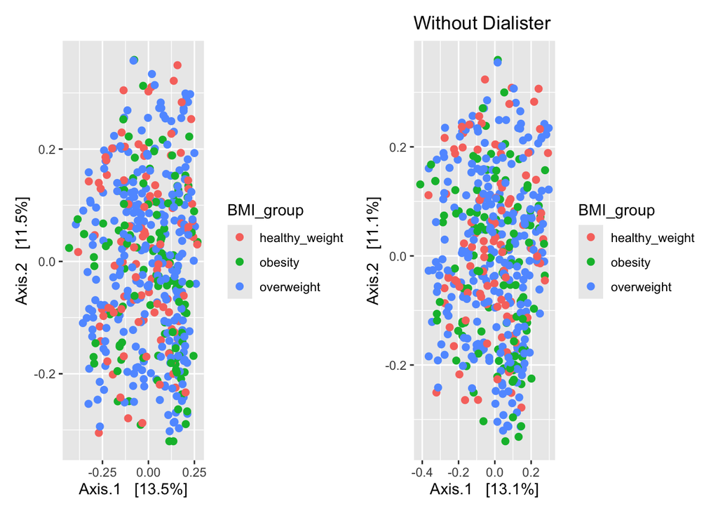

```r
# adding ordination plot
ps_ord_1 <- ordinate(ps_g, method = "PCoA", distance = "unifrac")

ps_ord_nondia <- ordinate(ps_nondia, method = "PCoA", distance = "unifrac")


ord_plot1 <- plot_ordination(ps_g, ps_ord_1,  color = "BMI_group") +
    geom_point(size = 2)

ord_plot2 <- plot_ordination(ps_nondia, ps_ord_nondia,  color = "BMI_group") +
    geom_point(size = 2) +
  #coord_fixed(xlim = c(-1.8, 1.8), ylim = c(-1.8,1.8)) +
  ggtitle(paste("Without Dialister"))

ord_plot1 + ord_plot2
```

# Mobiluncus

Mobiluncus is associated with PSAGAIN (via HAllA)

```r
ps_mob <- ps_g_rel %>%
  subset_taxa(., Genus == "Mobiluncus")
```

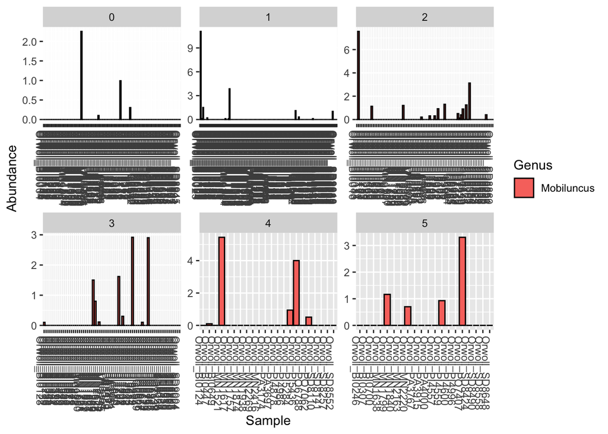

```r
plot_bar(ps_mob, x = "Sample", y = "Abundance", fill = "Genus") + facet_wrap(~PSAGAIN, scales = "free")
```

### How many people have Mobiluncus?

```r
ps_mob <- subset_samples(ps_mob, taxa_sums(ps_mob) > 0)
ps_mob <- prune_samples(sample_sums(ps_mob) >0, ps_mob)

ps_m <- ps_g_rel %>%
  subset_samples(., (sample_names(ps_g_rel) %in% sample_names(ps_mob)))

ps_m <- subset_taxa(ps_m, taxa_sums(ps_m) >0)

meta_m <- data.frame(ps_m@sam_data)
```

There are 48 people with Mobiluncus.

### Rel abundance

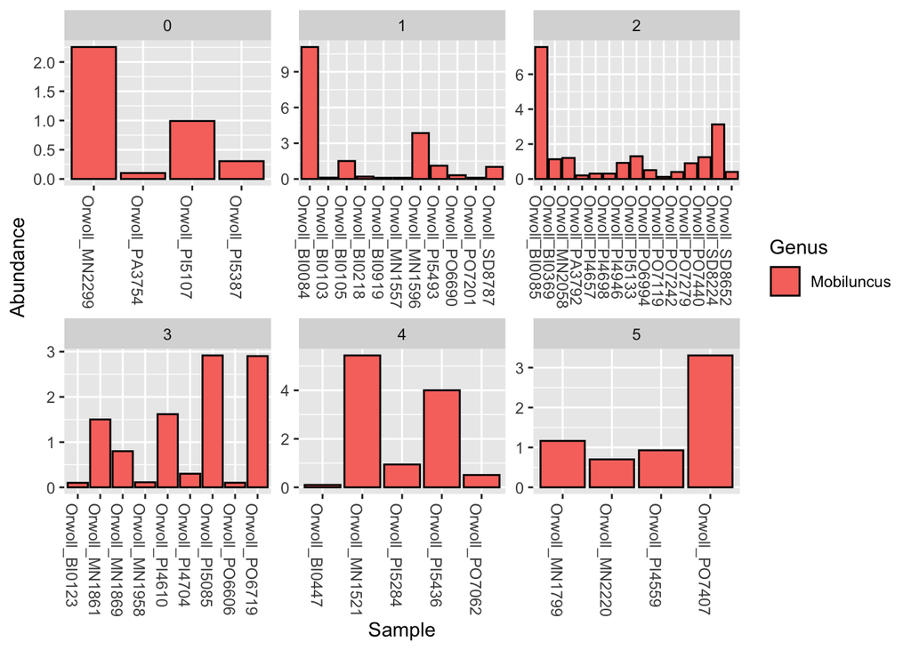

```r
ps_m %>%
  subset_taxa(., Genus == "Mobiluncus") %>%
  plot_bar(., x = "Sample", y = "Abundance", fill = "Genus") + facet_wrap(~PSAGAIN, scales = "free")
```

### Rel abundance - boxplots

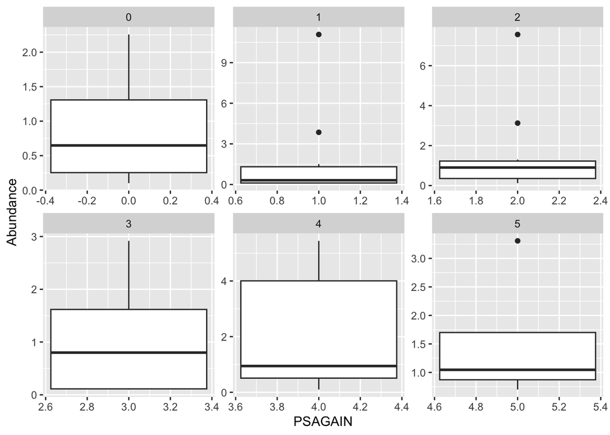

```r
ps_m %>%
  subset_taxa(., Genus == "Mobiluncus") %>%
  psmelt() %>%
  ggplot(., aes(x = PSAGAIN, y = Abundance)) + geom_boxplot() + facet_wrap(~PSAGAIN, scales = "free")
```

```r
m_smelt <-
  ps_m %>%
  subset_taxa(., Genus == "Mobiluncus") %>%
  psmelt()
```

#### stats

```r
# Compute the analysis of variance
res.aov <- aov(Abundance ~ PSAGAIN, data = m_smelt)
# Summary of the analysis
summary(res.aov)
```

```
##             Df Sum Sq Mean Sq F value Pr(>F)
## PSAGAIN      1   0.44   0.443     0.1  0.753
## Residuals   46 203.61   4.426
```

```r
# Test for normality
shapiro.test(d_smelt$Abundance) # Non-normal! ... so anova is not appropriate
```

```
##
##  Shapiro-Wilk normality test
##
## data:  d_smelt$Abundance
## W = 0.66975, p-value = 2.187e-14
```

```r
kruskal.test(Abundance ~ PSAGAIN, data = m_smelt)
```

```
##
##  Kruskal-Wallis rank sum test
##
## data:  Abundance by PSAGAIN
## Kruskal-Wallis chi-squared = 1.8942, df = 5, p-value = 0.8636
```

### proportion test

Ref: http://www.sthda.com/english/wiki/two-proportions-z-test-in-r#what-is-two-proportions-z-test

```r
# x: # of people with Mobiluncus
# n: total # of people in that group

prop.test(x = c(4, 11, 15, 9, 5, 4), n = c(113, 167, 83, 70, 22, 20), p = NULL, alternative = "two.sided",
          correct = TRUE)
```

```
##
##  6-sample test for equality of proportions without continuity correction
##
## data:  c(4, 11, 15, 9, 5, 4) out of c(113, 167, 83, 70, 22, 20)
## X-squared = 20.035, df = 5, p-value = 0.001231
## alternative hypothesis: two.sided
## sample estimates:
##     prop 1     prop 2     prop 3     prop 4     prop 5     prop 6
## 0.03539823 0.06586826 0.18072289 0.12857143 0.22727273 0.20000000
```

# Staph

Staph is associated with BMI_group (according to HAllA)

```r
ps_staph <- ps_g_rel %>%
  subset_taxa(., Genus == "Staphylococcus")
```

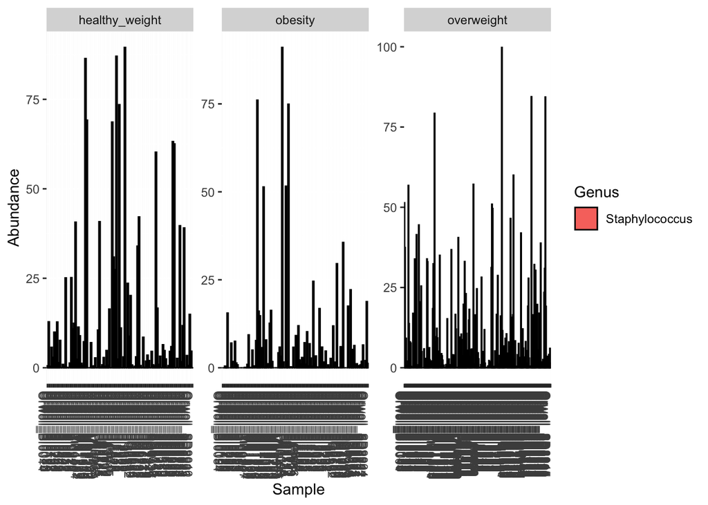

```r
plot_bar(ps_staph, x = "Sample", y = "Abundance", fill = "Genus") + facet_wrap(~BMI_group, scales = "free")
```

### How many people have Staph?

```r
ps_staph <- subset_samples(ps_staph, taxa_sums(ps_staph) > 0)
ps_staph <- prune_samples(sample_sums(ps_staph) >0, ps_staph)

ps_s <- ps_g_rel %>%
  subset_samples(., (sample_names(ps_g_rel) %in% sample_names(ps_staph)))

ps_s <- subset_taxa(ps_s, taxa_sums(ps_s) >0)

meta_s <- data.frame(ps_s@sam_data)
```

There are 372 people that have staph in their urinary microbiomes.

### Rel abundance

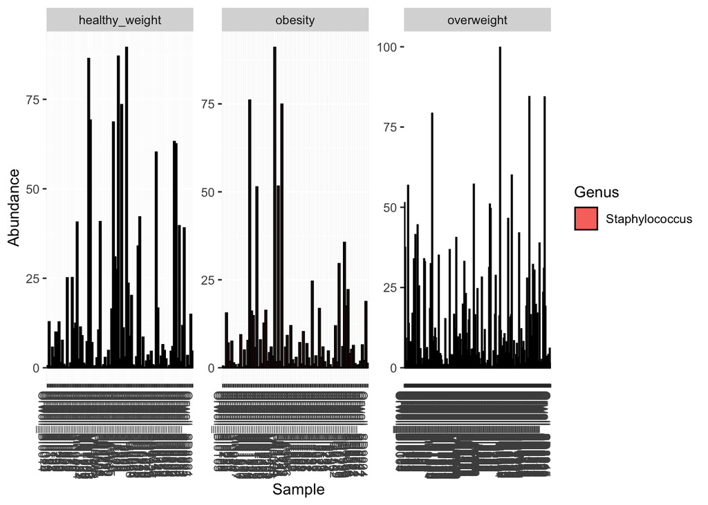

```r
ps_s %>%
  subset_taxa(., Genus == "Staphylococcus") %>%
  plot_bar(., x = "Sample", y = "Abundance", fill = "Genus") + facet_wrap(~BMI_group, scales = "free")
```

Healthy weight: 89/104 –> 85.6% Overweight: 201/253 –> 79.4% Obesity: 82/118 –> 69.5%

### Rel abundance - boxplots

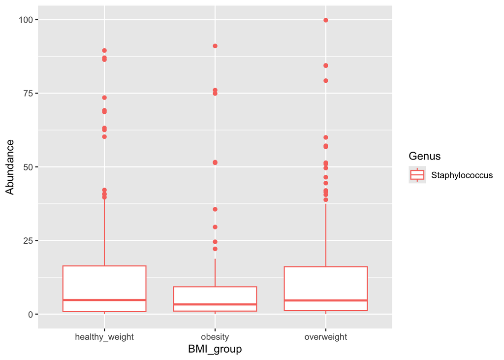

```r
ps_s %>%
  subset_taxa(., Genus == "Staphylococcus") %>%
  psmelt() %>%
  ggplot(., aes(x = BMI_group, y = Abundance, color = Genus)) + geom_boxplot()
```

```r
s_smelt <-
  ps_s %>%
  subset_taxa(., Genus == "Staphylococcus") %>%
  psmelt()
```

#### stats

```r
# Compute the analysis of variance
res.aov <- aov(Abundance ~ BMI_group, data = s_smelt)
# Summary of the analysis
summary(res.aov)
```

```
##              Df Sum Sq Mean Sq F value Pr(>F)
## BMI_group     2   1342   670.9   1.945  0.144
## Residuals   369 127302   345.0
```

```r
# Test for normality
shapiro.test(s_smelt$Abundance) # Non-normal! ... so anova is not appropriate
```

```
##
##  Shapiro-Wilk normality test
##
## data:  s_smelt$Abundance
## W = 0.66008, p-value < 2.2e-16
```

```r
kruskal.test(Abundance ~ BMI_group, data = s_smelt)
```

```
##
##  Kruskal-Wallis rank sum test
##
## data:  Abundance by BMI_group
## Kruskal-Wallis chi-squared = 2.6101, df = 2, p-value = 0.2712
```

### proportion test

Ref: http://www.sthda.com/english/wiki/two-proportions-z-test-in-r#what-is-two-proportions-z-test

```r
# x: # of people with Staphylococcus
# n: total # of people in that group

prop.test(x = c(89, 201, 82), n = c(104, 253, 118), p = NULL, alternative = "two.sided",
          correct = TRUE)
```

```
##
##  3-sample test for equality of proportions without continuity correction
##
## data:  c(89, 201, 82) out of c(104, 253, 118)
## X-squared = 8.83, df = 2, p-value = 0.01209
## alternative hypothesis: two.sided
## sample estimates:
##    prop 1    prop 2    prop 3
## 0.8557692 0.7944664 0.6949153
```

# Diabetes and Bacteroidetes

Diabetes is associated with Bacteroidetes (according to HAllA)

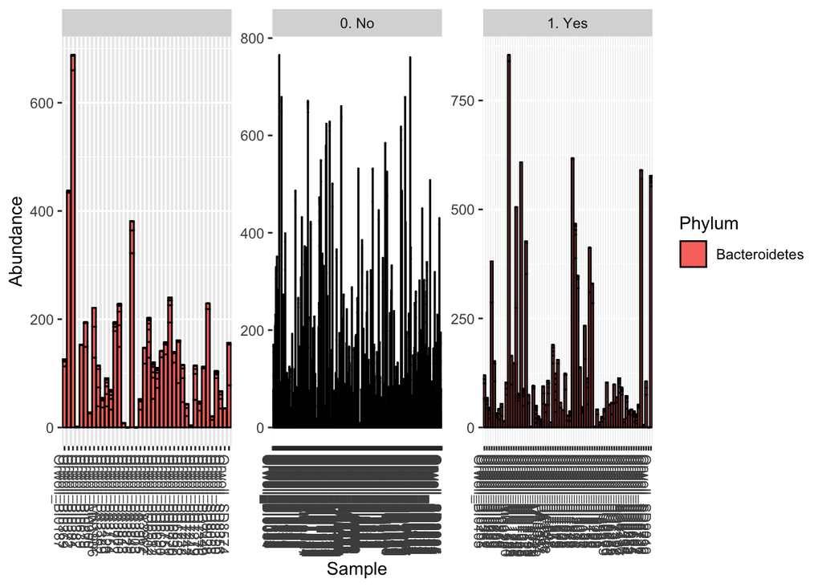

```r
ps_bac <- ps_g %>%
  subset_taxa(., Phylum == "Bacteroidetes")

plot_bar(ps_bac, x = "Sample", y = "Abundance", fill = "Phylum") + facet_wrap(~Diabetes, scales = "free")
```

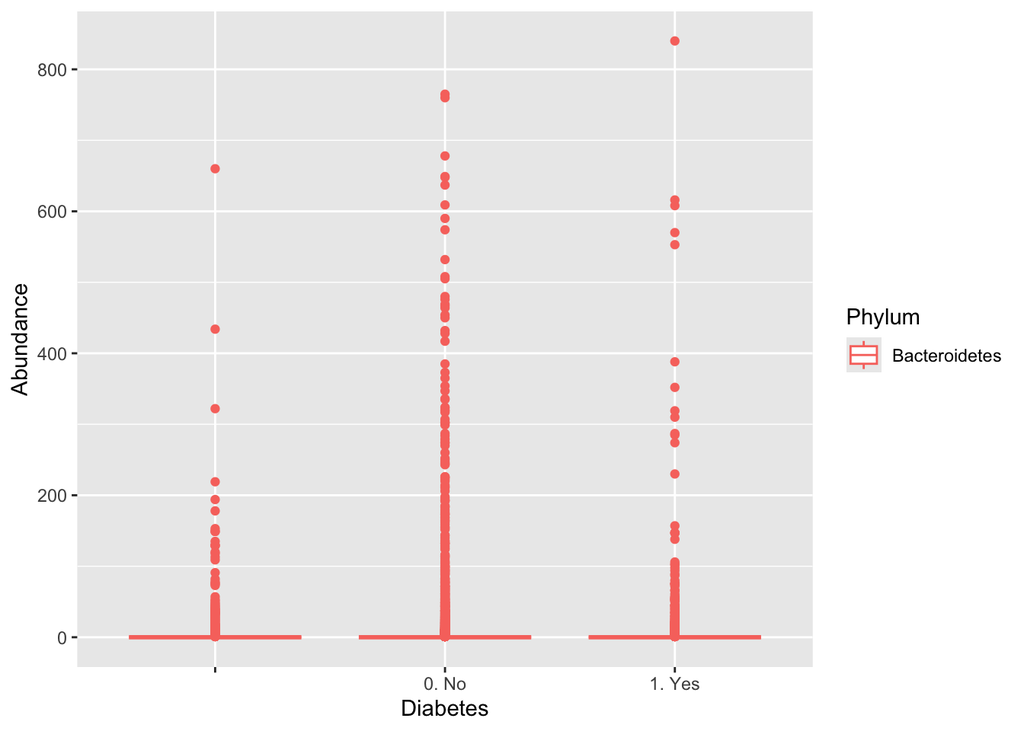

```r
ps_bac %>%
  psmelt() %>%
  ggplot(., aes(x = Diabetes, y = Abundance, color = Phylum)) + geom_boxplot()
```

### How many people have Bacteroidetes?

```r
ps_bac <- subset_samples(ps_bac, taxa_sums(ps_bac) > 0)
ps_bac <- prune_samples(sample_sums(ps_bac) >0, ps_bac)

ps_b <- ps_g_rel %>%
  subset_samples(., (sample_names(ps_g_rel) %in% sample_names(ps_bac)))

ps_b <- subset_taxa(ps_b, taxa_sums(ps_b) >0)
ps_b <- subset_samples(ps_b, Diabetes != "")

meta_b <- data.frame(ps_b@sam_data)
```

There are 439 people that have Bacteroidetes in their urinary microbiomes. 401 people reported Yes/No on diabetes.

### Rel abundance

```r
table(meta_b$Diabetes)
```

```
##
##  0. No 1. Yes
##    333     68
```

```r
table(meta_ps$Diabetes)
```

```
##
##         0. No 1. Yes
##     40    366     69
```

Yes: 68/69 –> 98.6% No: 333/366 –> 91.0% NA: 38/40 –> 95.0%

### Rel abundance - boxplots

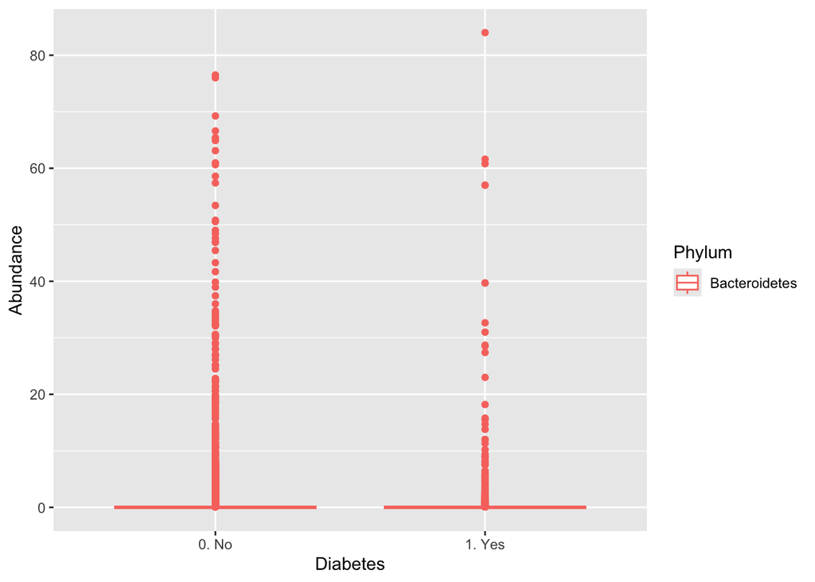

```r
ps_b %>%
  subset_taxa(., Phylum == "Bacteroidetes") %>%
  psmelt() %>%
  ggplot(., aes(x = Diabetes, y = Abundance, color = Phylum)) + geom_boxplot()
```

```r
b_smelt <-
  ps_b %>%
  subset_taxa(., Phylum == "Bacteroidetes") %>%
  psmelt()
```

#### stats

```r
# Compute the analysis of variance
res.aov <- aov(Abundance ~ Diabetes, data = b_smelt)
# Summary of the analysis
summary(res.aov)
```

```
##                Df Sum Sq Mean Sq F value Pr(>F)
## Diabetes        1      0   0.328   0.044  0.834
## Residuals   21251 159189   7.491
```

```r
kruskal.test(Abundance ~ Diabetes, data = b_smelt)
```

```
##
##  Kruskal-Wallis rank sum test
##
## data:  Abundance by Diabetes
## Kruskal-Wallis chi-squared = 0.086332, df = 1, p-value = 0.7689
```

# Figure 1

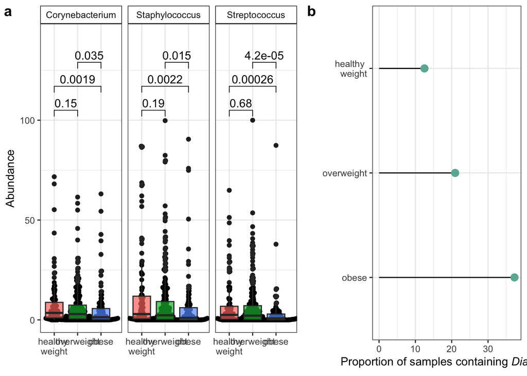

```r
plot_grid(BMI_genera, BMI_lolli, labels = c("a", "b"), rel_widths = c(1.35, 1))
```